# Turnover Analytics Insights Report

Mohammed Alhaqbani

30/9/2023

## *Disclaimer*

**Note:** This information and salary data are not real and have been randomly generated for practice purposes.

Understanding Employee Turnover

**Employee Turnover** refers to the phenomenon of an employee ending their formal relationship with an organization. In essence, it signifies the gradual loss or exit of employees over time. The terms - *employee churn*, *employee turnover*, and *employee attrition* - are often used interchangeably in the corporate domain.

Why Employee Turnover Matters?

Employees, being the cornerstone of an organization, accentuate its value. A predominant challenge that organizations grapple with today is employee retention. Alarmingly, a vast segment, almost a quarter of all U.S. workers, opts to resign annually. In specific sectors, this rate takes a dramatic leap. Citing the **Society of Human Resource Management (SHRM)**, the financial implications of replacing an employee can range from 50-60% of the employee’s salary, with overarching costs surging to 90-200%.

Types of Employee Turnover

Employee turnover can be dichotomized into: - **Voluntary Turnover**: This transpires when an employee, on their volition, chooses to resign. - **Involuntary Turnover**: This is an organizational call, where the entity decides to release an employee. This could stem from contractual obligations, organizational restructuring, or disciplinary measures.

Hidden Reasons for Employee Turnover

Underlying reasons for exits often remain shrouded in mystery as employees generally refrain from disclosing them. This course promises revelations, unearthing hidden reasons that might propel turnover. Factors like relationships with superiors, recent salary revisions, extended working hours, commute duration, career satisfaction, and tenure could be pivotal.

## Data exploration

First 10 records of org_data

| emp_id | status | turnover | location | level | date_of_joining | date_of_birth | last_working_date | gender | department | mgr_id | cutoff_date | generation | emp_age |
| --- | --- | --- | --- | --- | --- | --- | --- | --- | --- | --- | --- | --- | --- |
| E11061 | Inactive | 1 | New York | Analyst | 22/03/2012 | 22/03/1992 | 11/09/2014 | Male | Customer Operations | E1712 | 31/12/2014 | Millennials | 22.5 |
| E1031 | Inactive | 1 | New York | Analyst | 09/03/2012 | 10/01/1992 | 05/06/2014 | Female | Customer Operations | E10524 | 31/12/2014 | Millennials | 22.4 |
| E6213 | Inactive | 1 | New York | Analyst | 06/01/2012 | 06/02/1992 | 30/04/2014 | Female | Customer Operations | E4443 | 31/12/2014 | Millennials | 22.2 |
| E5900 | Inactive | 1 | New York | Analyst | 22/03/2012 | 19/12/1991 | 09/04/2014 | Female | Customer Operations | E3638 | 31/12/2014 | Millennials | 22.3 |
| E3044 | Inactive | 1 | Florida | Analyst | 29/03/2012 | 10/12/1991 | 23/01/2014 | Female | Customer Operations | E3312 | 31/12/2014 | Millennials | 22.1 |
| E4008 | Active | 0 | Florida | Assistant Manager | 27/11/2013 | 06/05/1992 | NA | Female | Customer Operations | E13933 | 31/12/2014 | Millennials | 23.0 |
| E6636 | Active | 0 | New York | Specialist | 17/02/2012 | 23/01/1992 | NA | Male | Customer Operations | E12038 | 31/12/2014 | Millennials | 23.0 |
| E13796 | Inactive | 1 | New York | Analyst | 30/03/2012 | 19/12/1990 | 11/05/2014 | Male | Customer Operations | E10524 | 31/12/2014 | Millennials | 23.4 |
| E13549 | Active | 0 | New York | Analyst | 09/03/2012 | 22/12/1991 | NA | Male | Customer Operations | E10524 | 31/12/2014 | Millennials | 23.0 |
| E13430 | Inactive | 1 | New York | Analyst | 09/03/2012 | 19/08/1991 | 16/10/2014 | Female | Customer Operations | E12897 | 31/12/2014 | Millennials | 23.2 |

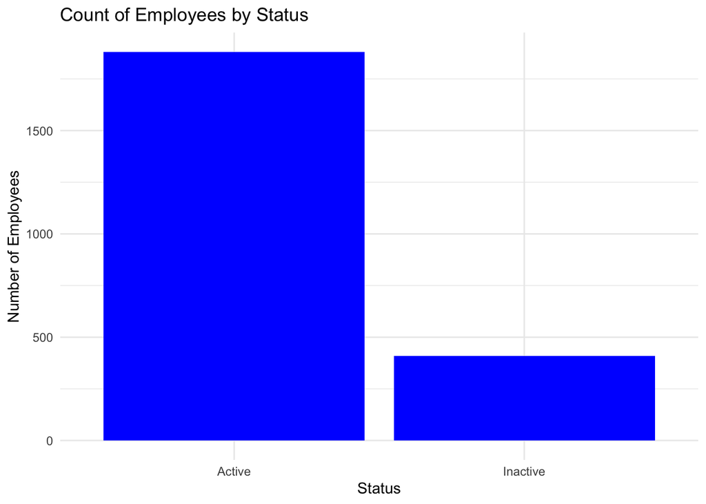

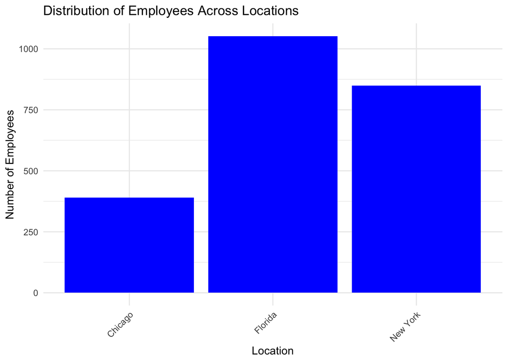

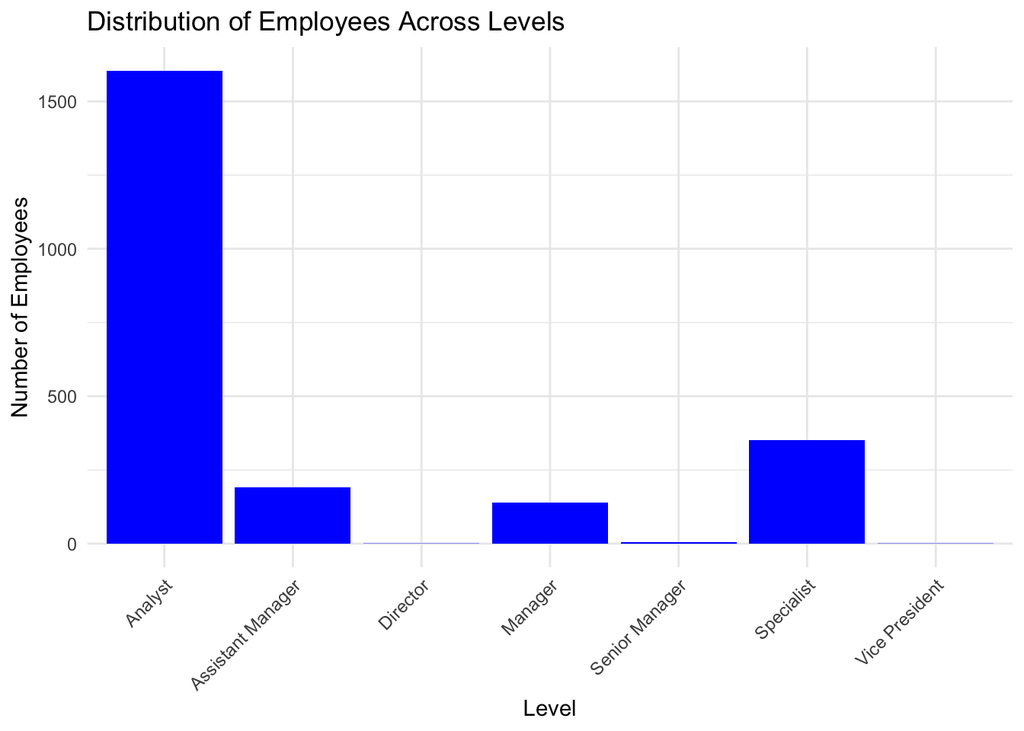

## What proportion of employees have left?

| level | total_employees | inactive_employees | turnover_rate |
| --- | --- | --- | --- |
| Analyst | 1604 | 345 | 21.508728 |
| Specialist | 350 | 52 | 14.857143 |
| Manager | 138 | 6 | 4.347826 |
| Assistant Manager | 192 | 7 | 3.645833 |
| Director | 1 | 0 | 0.000000 |
| Senior Manager | 5 | 0 | 0.000000 |
| Vice President | 1 | 0 | 0.000000 |

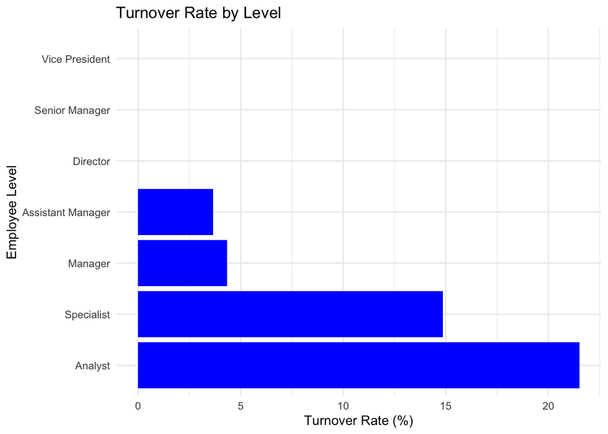

Turnover by Location

| location | total_employees | employees_left | turnover_rate |
| --- | --- | --- | --- |
| Chicago | 390 | 127 | 32.56410 |
| Florida | 1052 | 111 | 10.55133 |
| New York | 849 | 172 | 20.25913 |

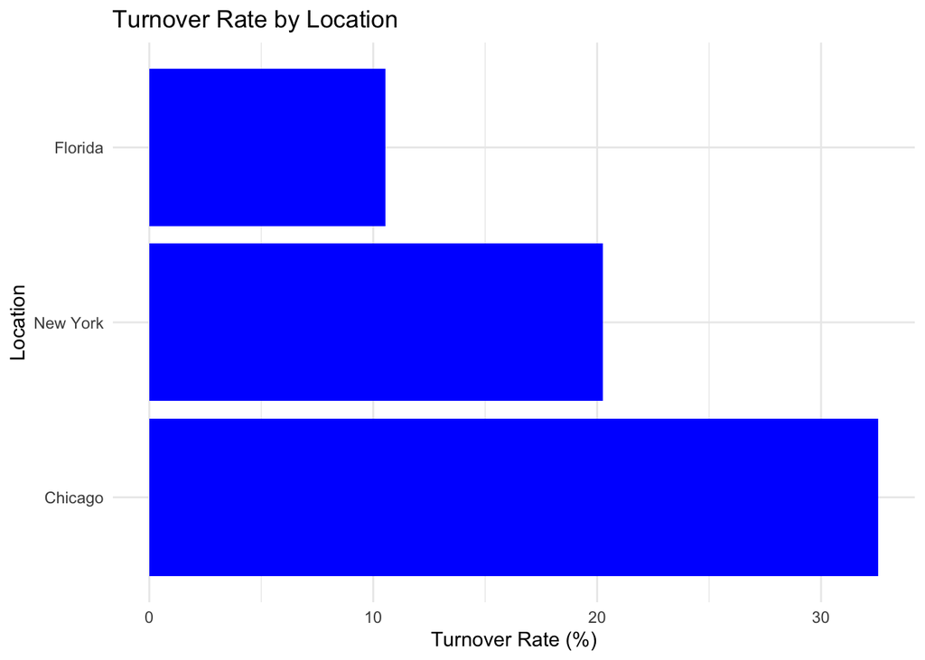

Employee Counts by Level for Analyst and Specialist

| level | n |
| --- | --- |
| Analyst | 1604 |
| Specialist | 350 |

|  | emp_id | status | turnover | location | level | date_of_joining | date_of_birth | last_working_date | gender | department | mgr_id | cutoff_date | generation | emp_age | rating |
| --- | --- | --- | --- | --- | --- | --- | --- | --- | --- | --- | --- | --- | --- | --- | --- |
| 1 | E11061 | Inactive | 1 | New York | Analyst | 22/03/2012 | 22/03/1992 | 11/09/2014 | Male | Customer Operations | E1712 | 31/12/2014 | Millennials | 22.5 | Acceptable |
| 2 | E1031 | Inactive | 1 | New York | Analyst | 09/03/2012 | 10/01/1992 | 05/06/2014 | Female | Customer Operations | E10524 | 31/12/2014 | Millennials | 22.4 | Acceptable |
| 3 | E6213 | Inactive | 1 | New York | Analyst | 06/01/2012 | 06/02/1992 | 30/04/2014 | Female | Customer Operations | E4443 | 31/12/2014 | Millennials | 22.2 | Acceptable |
| 4 | E5900 | Inactive | 1 | New York | Analyst | 22/03/2012 | 19/12/1991 | 09/04/2014 | Female | Customer Operations | E3638 | 31/12/2014 | Millennials | 22.3 | Acceptable |
| 5 | E3044 | Inactive | 1 | Florida | Analyst | 29/03/2012 | 10/12/1991 | 23/01/2014 | Female | Customer Operations | E3312 | 31/12/2014 | Millennials | 22.1 | Acceptable |
| 6 | E6636 | Active | 0 | New York | Specialist | 17/02/2012 | 23/01/1992 | NA | Male | Customer Operations | E12038 | 31/12/2014 | Millennials | 23.0 | Above Average |

Turnover Rate by Rating

| rating | turnover_count | total_count | turnover_rate |
| --- | --- | --- | --- |
| Above Average | 73 | 556 | 0.1312950 |
| Acceptable | 236 | 1068 | 0.2209738 |
| Below Average | 65 | 169 | 0.3846154 |
| Excellent | 4 | 131 | 0.0305344 |
| Unacceptable | 19 | 30 | 0.6333333 |

Mean Effectiveness Score by Status

| status | mean_effectiveness_score |
| --- | --- |
| Active | 0.7081689 |
| Inactive | 0.5685164 |

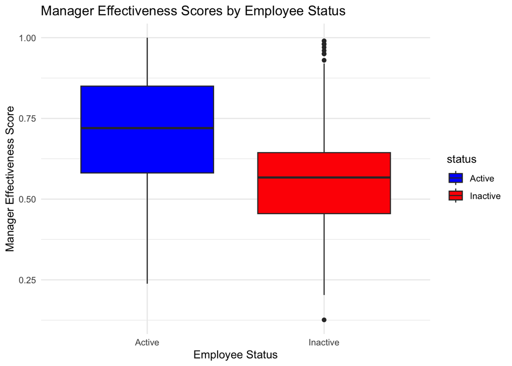

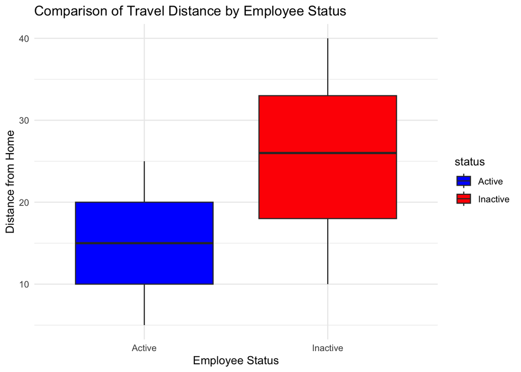

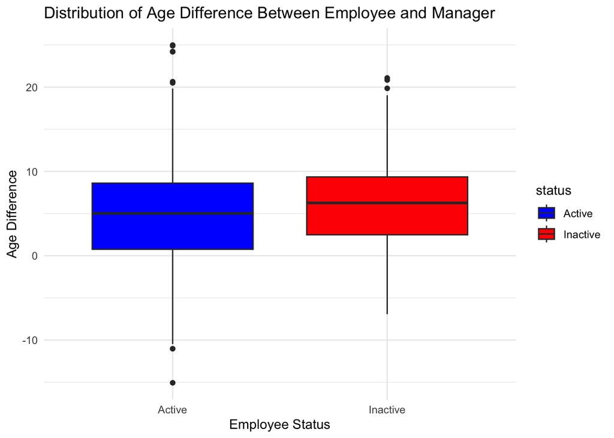

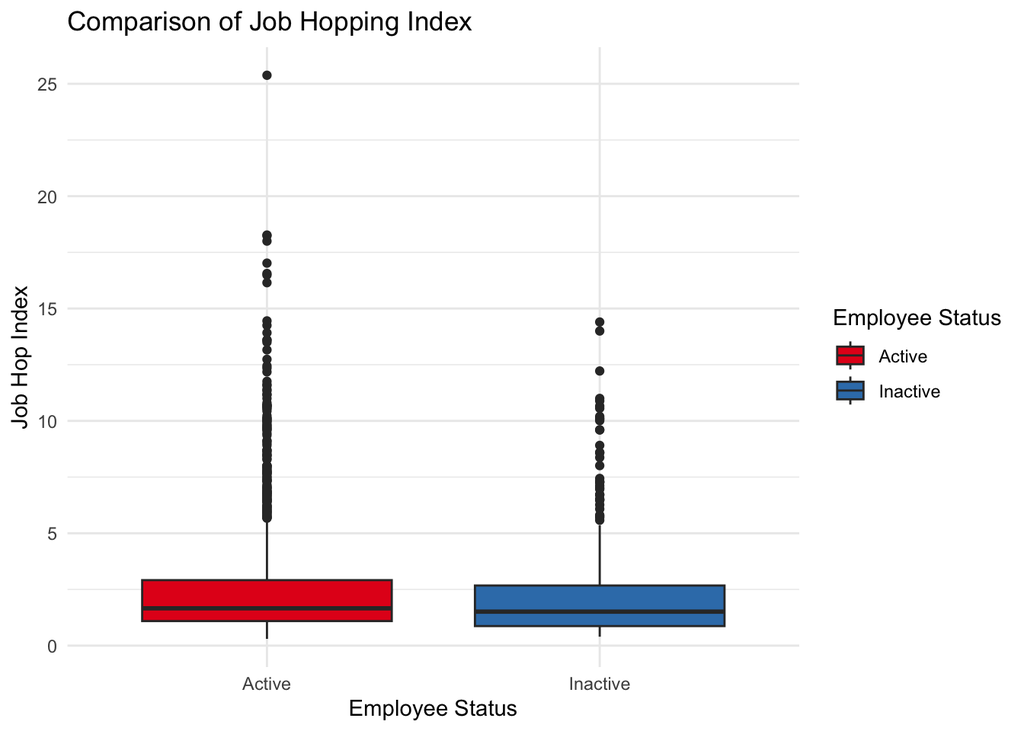

| emp_id | status | location | level | gender | emp_age | rating | mgr_rating | mgr_reportees | mgr_age | mgr_tenure | compensation | percent_hike | hiring_score | hiring_source | no_previous_companies_worked | distance_from_home | total_dependents | marital_status | education | promotion_last_2_years | no_leaves_taken | total_experience | monthly_overtime_hrs | date_of_joining | last_working_date | department | mgr_id | cutoff_date | turnover | … |
| --- | --- | --- | --- | --- | --- | --- | --- | --- | --- | --- | --- | --- | --- | --- | --- | --- | --- | --- | --- | --- | --- | --- | --- | --- | --- | --- | --- | --- | --- | --- |
| E10012 | Active | New York | Analyst | Female | 25.09 | Above Average | Acceptable | 9 | 44.07 | 3.17 | 64320 | 10 | 70 | Consultant | 0 | 14 | 2 | Single | Bachelors | No | 2 | 6.86 | 1 | 2011-03-06 |  | Customer Operations | E9335 | 2014-12-31 | 0 | … |
| E10025 | Active | Chicago | Analyst | Female | 25.98 | Acceptable | Excellent | 4 | 35.99 | 7.92 | 48204 | 8 | 70 | Job Fairs | 9 | 21 | 2 | Single | Bachelors | No | 10 | 4.88 | 5 | 2009-09-23 |  | Customer Operations | E6655 | 2014-12-31 | 0 | … |
| E10027 | Active | Orlando | Specialist | Female | 33.40 | Acceptable | Above Average | 6 | 35.78 | 4.38 | 85812 | 11 | 77 | Consultant | 3 | 15 | 5 | Single | Bachelors | Yes | 18 | 8.55 | 3 | 2005-11-02 |  | Customer Operations | E13942 | 2014-12-31 | 0 | … |
| E10048 | Active | Chicago | Specialist | Male | 24.55 | Acceptable | Acceptable | 10 | 26.70 | 2.87 | 49536 | 8 | 71 | Job Boards | 5 | 9 | 3 | Single | Bachelors | Yes | 19 | 4.76 | 8 | 2011-05-20 |  | Customer Operations | E7063 | 2014-12-31 | 0 | … |
| E10060 | Active | Orlando | Analyst | Male | 31.23 | Acceptable | Acceptable | 11 | 34.28 | 12.95 | 75576 | 12 | 70 | Job Fairs | 0 | 25 | 4 | Single | Bachelors | No | 25 | 8.06 | 1 | 2011-12-21 |  | Customer Operations | E5663 | 2014-12-31 | 0 | … |
| E10061 | Inactive | Orlando | Analyst | Male | 31.98 | Below Average | Above Average | 19 | 34.82 | 10.88 | 56904 | 8 | 75 | Job Boards | 8 | 23 | 5 | Single | Masters | No | 15 | 13.72 | 7 | 2009-09-18 | 2014-12-11 | Customer Operations | E4715 | 2014-12-31 | 1 | … |

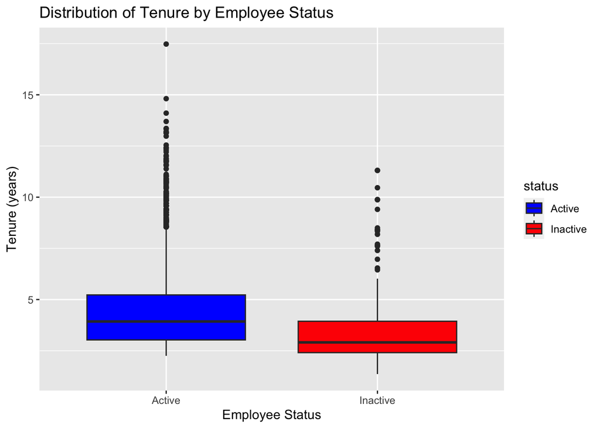

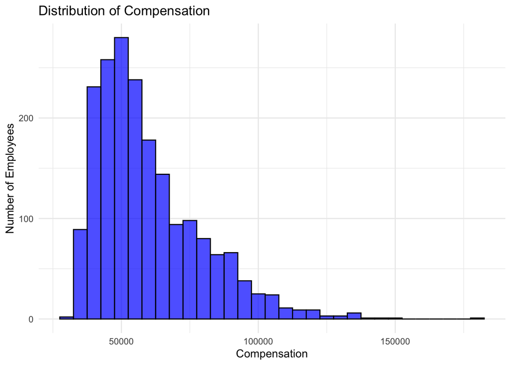

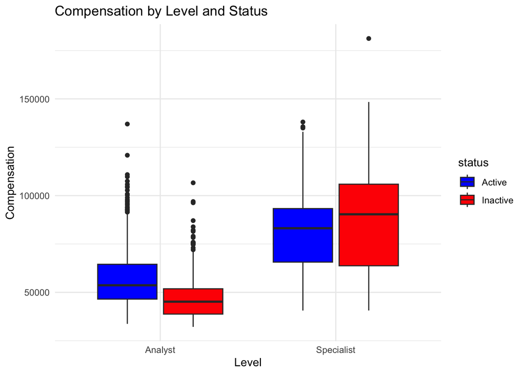

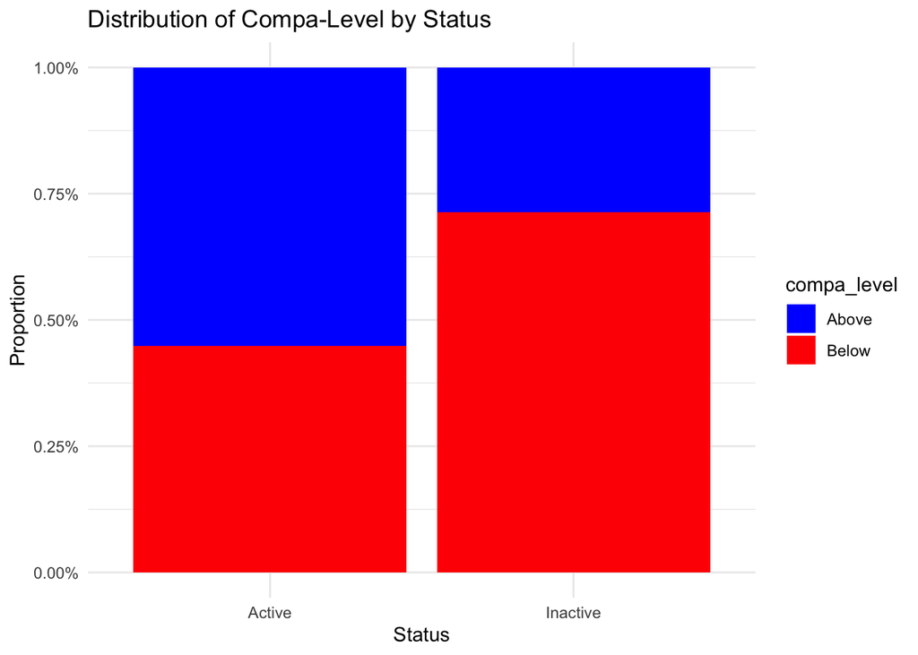